# MCMC Sampling to Bayesian Modeling

Jiaxing Qiu, Shenghua Wu

12/13/2019

## Part 1 - Background Knowledge

### Bayesian Statistical Modeling

- Bayes Theorem
  $$\begin{align*}
  f(\theta | x) = \frac{f(x|\theta)g(\theta)}{\int f(x|\theta)g(\theta) d\theta}
  \end{align*}$$
- Components:
  - posterior distribution $f(\theta | x)$
  - likelihood $f(x|\theta)$
  - prior distribution $g(\theta)$
  - normalizing constant $\int f(x|\theta)g(\theta) d\theta$
- Regular vs. Bayesian
  - Regular Machine Learning process is a set of methods for creating predictive or inferential models only based on observed data.
  - Bayesian Mechine Learning is an approach to specify and fit a model that combines prior beliefs with the observed data.
  - Under the framework of Bayesian statistics, a regular machine learning model can be viewed as a special case with no prior information given, in other words, we choose a uninformative prior (constant distribution) for the model.

### Sampling approach - MCMC method

- Mante Carlo Estimation
  - After we make the assumptions for the model in terms of probability distributions, use the observed data to fit the model, and finally calculate the values for the unknown parameters, we get the closed form of that distribution.
  - Then we want to generate inferential information from our model based on important statistics (quantities). These statistics of interest can be the mean, the mode, the variance, or the probability of some events.
  - All of these calculation involves integration, which can be very difficult or impossible to get a close-formed expression that contains only known parameters. i.e. The formular for expected value(mean) is as follows:
    $$\begin{align*}
    E(\theta) = \int{\theta p(\theta)}d\theta
    \end{align*}$$
  - Monte Carlo estimation refers to simulating hypothtical draws from a complicated probability distribution to estimate the statistics above without doing integratation.
  - The concept behind Monte Carlo estimation is nothing more than Central Limit Theorem. More details can be found in the following Wikipedia link: https://en.wikipedia.org/wiki/Central_limit_theorem .
- Markov Chain
  - Markov assumption:
    $$\begin{align*}
    p(X_{t+1} | X_{t},X_{t-1},...,X_{2},X_{1}) = p(X_{t+1} | X_{t})
    \end{align*}$$
  - Concept: Using a Markov Chain, the transition (choose the next sample/state) only depends on the current sample/state.
  - More details can be found in the following link: https://en.wikipedia.org/wiki/Markov_chain .
- Reasons for MCMC Sampling Methods
  - The integral in the normalizing constant term in Bayesia model is most time intractable, and the format of posterior distribution is too complicated to be from any known probability distribution family.
  - Based on the concept of ‘Monte Carlo Estimation’, we can estimate the statistics of interest(i.e. mean, mode, standard deviation…) using the samples from posterior distribution directly.
  - Compared to other sampling methods (grid search, rejection sampling, importance sampling, etc.), Markov Chain Monte Carlo sampling method works better on:
    1. it can sample from more complicated posterior distributions at a faster speed.
    2. we only need to specify two components in a bayesian model - the prior and likelihood, before running a MCMC algorithm. It requiers neither the exact expression of the posterior distribution, nor the integratation in the normalizing constant at all.

### Practise with R

- R packages for MCMC
  - The package we can use to conduct MCMC methods in R includes ‘JAGS(Juat Another Gibbs Sampler)’, ‘rjags’ and ‘R2jags’.
  - To download, install and set up these packages, we can follow the instructiona in this link: http://mcmc-jags.sourceforge.net
- Main steps for modeling in ‘JAGS’
  - 1. Specify the model
  - 2. Set up the model
  - 3. Run the MCMC sampler
  - 4. Post processing

## Part 2 - Case Study

To show how to use MCMC sampling methods for Bayesian modeling, we will use a real-world case to explore a food recipe and an intercation dataset. (https://www.kaggle.com/shuyangli94/food-com-recipes-and-user-interactions/data#RAW_recipes.csv) We are trying to find predictive relationships between recipes and customer reviews and mine interesting insights from recipes. We aimed to answer two specific questions: First, classify customer reviews to two categories (high as 5 or low as 1-4), based on minutes to cook, number of steps, number of ingredients, calories and six nutrition facts (total fat, sugar, sodium, protein, saturated_fat, carbohydrates) of a recipe. Second, predict calories of a recipe, using these six nutrition facts. Such insights could predict fundamental recipe properties, such as calories and cooking/preparation time, and understand users’ behavior and preferences. This knowledge could be used to encourage healthy dietary choices.

```r
# load packages
library('rjags')
library('coda')
library('dplyr')
```

### Problem 1

### Data

In this case, we are going to classify customer reviews. We did some feature engineering(not specified here) to the dataset and reached the following dataset.

| minutes | n_steps | n_ingredients | rating | calories | total_fat | sugar | sodium | protein | saturated_fat | carbohydrates |
| --- | --- | --- | --- | --- | --- | --- | --- | --- | --- | --- |
| 55 | 11 | 7 | 5 | 51.5 | 0 | 13 | 0 | 2 | 0 | 4 |
| 30 | 9 | 6 | 5 | 173.4 | 18 | 0 | 17 | 22 | 35 | 1 |
| 30 | 9 | 6 | 4 | 173.4 | 18 | 0 | 17 | 22 | 35 | 1 |
| 130 | 6 | 13 | 4 | 269.8 | 22 | 32 | 48 | 39 | 27 | 5 |
| 45 | 11 | 11 | 4 | 368.1 | 17 | 10 | 2 | 14 | 8 | 20 |
| 45 | 11 | 11 | 5 | 368.1 | 17 | 10 | 2 | 14 | 8 | 20 |

For this dataset, we will run logistic regression with and without hierachical priors. We will use rating as response variable (high as 5 or low as 1-4) and others as predictors. We first split the predictors and response variables. To make the model work efficiently in our computer, we will subset the training data to 1000 random data points.

```r
# ----- Predictors
X = data[, which(names(data) != 'rating')]
# ----- Response Variable
# add review column for 1/0 valued response: 1 - high-level review (rating == 5); 0 - low-level review (rating < 5)
data$review = ifelse(data$rating == 5, 1, 0)
Y = data$review

# subset original dataset to 1000 rows of training data by random sampling, scale the training data
set.seed(111)
index = sample(1:nrow(data), size = 1000, replace = FALSE)
X.train = data.frame(scale(X[index,], center = TRUE, scale = TRUE))
Y.train = Y[index]
```

#### Simple Logistic Regression

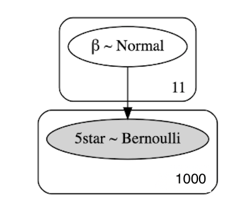

model1.1

##### 1. Specify the model

```r
mod_string = "model{
  for(i in 1:1000){
    y[i] ~ dbern(p[i])
    logit(p[i]) = itc + b[1]*minutes[i] + b[2]*n_steps[i] +
      b[3]*n_ingredients[i] + b[4]*calories[i] +
      b[5]*total_fat[i] + b[6]*sugar[i] + b[7]*sodium[i] +
      b[8]*protein[i] + b[9]*saturated_fat[i] +
      b[10]*carbohydrates[i]
  }
  # uninformative prior for intercept
  itc ~ dnorm(0.0, 1.0/25.0)
  # uninformative prior for coefficients
  for(j in 1:10){
    b[j] ~ dnorm(0.0, 1.0/25.0)
  }
}"
```

##### 2. Set up the Model

```r
# monitor target posterior parameters
params = c('b', 'itc')
# training data for the model
data_jags = list(y = Y.train,
                 minutes = X.train[,'minutes'],
                 n_steps = X.train[,'n_steps'],
                 n_ingredients = X.train[, 'n_ingredients'],
                 calories = X.train[,'calories'],
                 total_fat = X.train[,'total_fat'],
                 sugar = X.train[,'sugar'],
                 sodium = X.train[,'sodium'],
                 protein = X.train[,'protein'],
                 saturated_fat = X.train[,'saturated_fat'],
                 carbohydrates = X.train[,'carbohydrates'])
# generate jags model object
mod1.1 = jags.model(textConnection(mod_string), data = data_jags, n.chains = 3)
# burn-in
update(mod1.1, 1e3)
```

##### 3. Fit the model - run MCMC sampler

```r
mod1.1_sim = coda.samples(mod1.1, variable.names = params, n.iter = 5e3)
mod1.1_csim = as.mcmc(do.call(rbind, mod1.1_sim))
```

##### 4. Convergence Diagnose

```r
# traceplot per parameter
# plot(mod1.1_sim, ask = TRUE)
# gelman diagnose
gelman.diag(mod1.1_sim)
```

```
## Potential scale reduction factors:
##
##       Point est. Upper C.I.
## b[1]        1.00       1.00
## b[2]        1.00       1.01
## b[3]        1.00       1.00
## b[4]        1.31       1.84
## b[5]        1.29       1.80
## b[6]        1.00       1.00
## b[7]        1.00       1.00
## b[8]        1.24       1.68
## b[9]        1.00       1.00
## b[10]       1.30       1.82
## itc         1.00       1.00
##
## Multivariate psrf
##
## 1.18
```

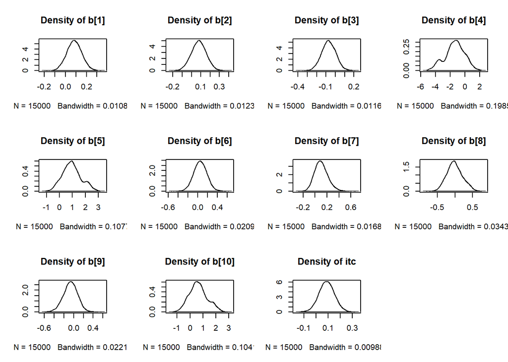

```r
# Model evaluation - DIC
dic1.1 = dic.samples(mod1.1, n.iter = 1e3)
# posterior distribution density plots
par(mfrow = c(3,4))
densplot(mod1.1_csim[,1:11])
```

#### Logistic Regression with Hierarchical Priors

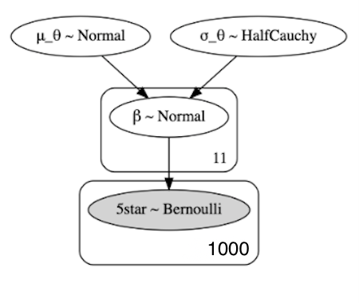

model1.2

##### 1. Specify the model

```r
mod_string = "model{
  for(i in 1:1000){
    y[i] ~ dbern(p[i])
    logit(p[i]) = itc + b[1]*minutes[i] + b[2]*n_steps[i] +
      b[3]*n_ingredients[i] + b[4]*calories[i] +
      b[5]*total_fat[i] + b[6]*sugar[i] + b[7]*sodium[i] +
      b[8]*protein[i] + b[9]*saturated_fat[i] +
      b[10]*carbohydrates[i]
  }

  # prior for intercept
  itc ~ dnorm(mu, prec)
  # prior for coefficients
  for(j in 1:10){
    b[j] ~ dnorm(mu, prec)
  }

  # prior for mu and precision of prior for intercept and coefficients
  mu ~ dnorm(0.0, 1.0/25.0)
  prec ~ dgamma(1/2.0, 1*10.0/2.0)

}"
```

##### 2. Set up the Model

```r
# monitor target posterior parameters
params = c('b', 'itc')
# training data for the model
data_jags = list(y = Y.train,
                 minutes = X.train[,'minutes'],
                 n_steps = X.train[,'n_steps'],
                 n_ingredients = X.train[, 'n_ingredients'],
                 calories = X.train[,'calories'],
                 total_fat = X.train[,'total_fat'],
                 sugar = X.train[,'sugar'],
                 sodium = X.train[,'sodium'],
                 protein = X.train[,'protein'],
                 saturated_fat = X.train[,'saturated_fat'],
                 carbohydrates = X.train[,'carbohydrates'])
# generate jags model object
mod1.2 = jags.model(textConnection(mod_string), data = data_jags, n.chains = 3)
# burn-in
update(mod1.2, 1e3)
```

##### 3. Fit model - run MCMC sampler

```r
mod1.2_sim = coda.samples(mod1.2, variable.names = params, n.iter = 5e3)
mod1.2_csim = as.mcmc(do.call(rbind, mod1.2_sim))
```

##### 4. Convergence Diagnose

```r
# traceplot
# plot(mod1.2_sim, ask = TRUE) # plot per parameter
# gelman diagnose
gelman.diag(mod1.2_sim)
```

```
## Potential scale reduction factors:
##
##       Point est. Upper C.I.
## b[1]        1.00       1.00
## b[2]        1.00       1.00
## b[3]        1.00       1.00
## b[4]        1.04       1.14
## b[5]        1.04       1.14
## b[6]        1.00       1.01
## b[7]        1.00       1.00
## b[8]        1.02       1.07
## b[9]        1.00       1.01
## b[10]       1.04       1.14
## itc         1.00       1.00
##
## Multivariate psrf
##
## 1.03
```

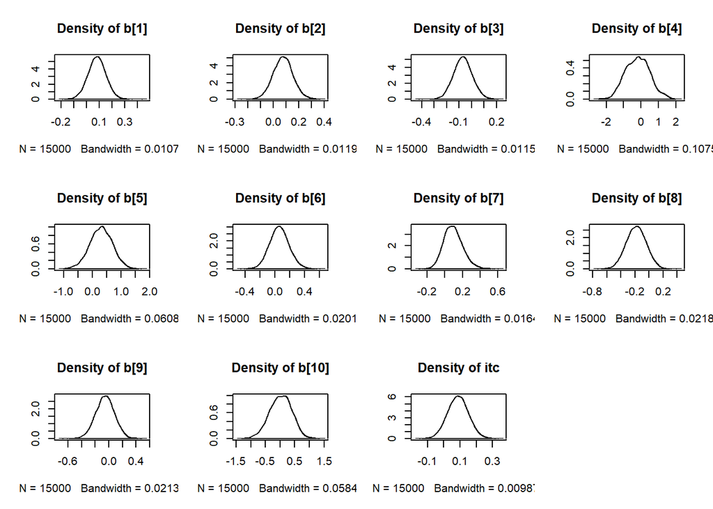

```r
# Model evaluation - DIC
dic1.2 = dic.samples(mod1.2, n.iter = 1e3)
# posterior distribution density plots
par(mfrow = c(3,4))
densplot(mod1.2_csim[,1:11])
```

##### 5. conclusion

From the density plots, the posterior distributions of coefficients we want to estimate converge well using MCMC sampling method, and give us point estimates for coefficients.

### Problem 2

#### Data

In this case, we are going to predict the caloires based on nutrition facts of the recipe. We used the same original dataset, and did some feature engineering and got the following table.

| calories | total_fat | sugar | sodium | protein | saturated_fat | carbohydrates |
| --- | --- | --- | --- | --- | --- | --- |
| 51.5 | 0 | 13 | 0 | 2 | 0 | 4 |
| 173.4 | 18 | 0 | 17 | 22 | 35 | 1 |
| 269.8 | 22 | 32 | 48 | 39 | 27 | 5 |
| 368.1 | 17 | 10 | 2 | 14 | 8 | 20 |
| 352.9 | 1 | 337 | 23 | 3 | 0 | 28 |
| 160.2 | 10 | 55 | 3 | 9 | 20 | 7 |

```r
# ----- Predictors
X = recipe[, which(names(recipe) != 'calories')]
# ----- Response Variable
Y = recipe$calories

# subset original dataset to 1000 rows of training data by random sampling, scale the training data
set.seed(222)
index = sample(1:nrow(recipe), size = 10000, replace = FALSE)
X.train = data.frame(scale(X[index,], center = TRUE, scale = TRUE))
Y.train = Y[index]
```

#### Simple Linear Regression with uninformative prior

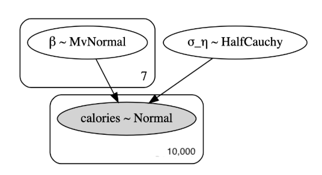

model2.1

##### 1. Specify the model

```r
mod_string = "model{
  for(i in 1:10000){
    y[i] ~ dnorm(mu[i], 1.0/25.0 )
    mu[i] = itc + b[1]*total_fat[i] + b[2]*sugar[i] + b[3]*sodium[i] +
      b[4]*protein[i] + b[5]*saturated_fat[i] + b[6]*carbohydrates[i]
  }
  # uninformative prior for intercept
  itc ~ dnorm(0.0, 1.0/25.0)
  # uninformative prior for coefficients
  for(j in 1:6){
    b[j] ~ dnorm(0.0, 1.0/25.0)
  }
}"
```

##### 2. Set up the Model

```r
# monitor target posterior parameters
params = c('b', 'itc')
# training data for the model
data_jags = list(y = Y.train,
                 total_fat = X.train[,'total_fat'],
                 sugar = X.train[,'sugar'],
                 sodium = X.train[,'sodium'],
                 protein = X.train[,'protein'],
                 saturated_fat = X.train[,'saturated_fat'],
                 carbohydrates = X.train[,'carbohydrates'])
# generate jags model object
mod2.1 = jags.model(textConnection(mod_string), data = data_jags, n.chains = 3)
# burn-in
update(mod2.1, 1e3)
```

##### 3. Fit model - run MCMC sampler

```r
mod2.1_sim = coda.samples(mod2.1, variable.names = params, n.iter = 5e3)
mod2.1_csim = as.mcmc(do.call(rbind, mod2.1_sim))
```

##### 4. Convergence Diagnose

```r
# traceplot
# plot(mod2.1_sim, ask = TRUE) # plot per parameter
# gelman diagnose
gelman.diag(mod2.1_sim)
```

```
## Potential scale reduction factors:
##
##      Point est. Upper C.I.
## b[1]          1       1.01
## b[2]          1       1.00
## b[3]          1       1.00
## b[4]          1       1.00
## b[5]          1       1.01
## b[6]          1       1.00
## itc           1       1.00
##
## Multivariate psrf
##
## 1
```

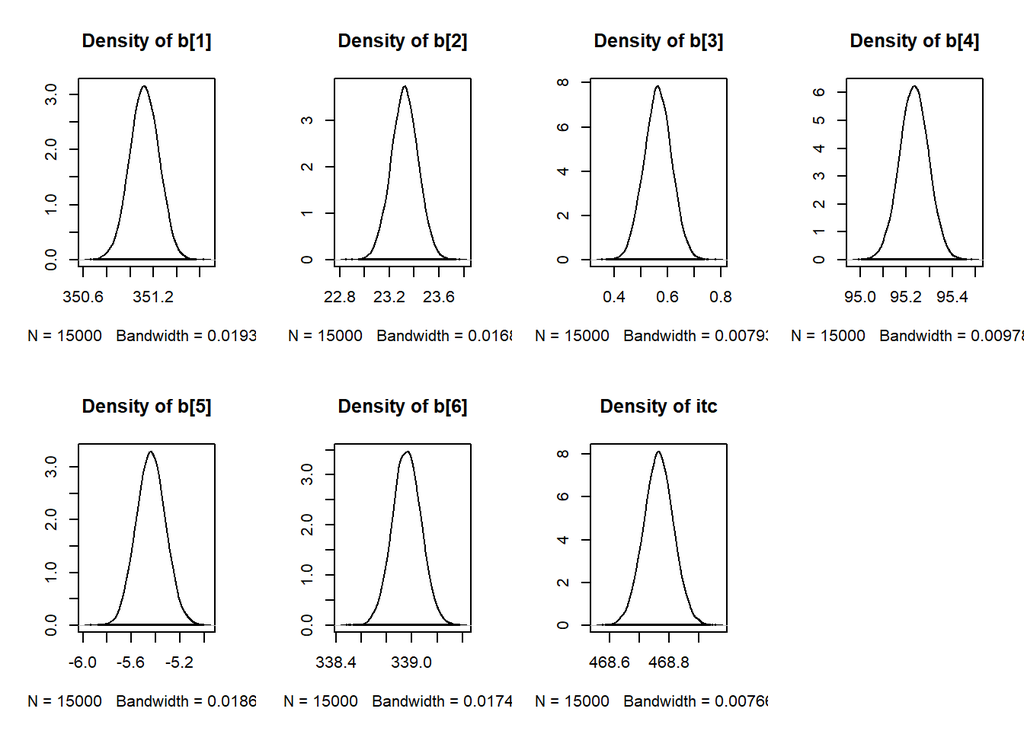

```r
# Model evaluation - DIC
dic2.1 = dic.samples(mod2.1, n.iter = 1e3)
# posterior distribution density plots
par(mfrow = c(2,4))
densplot(mod2.1_csim[,1:7])
```

##### 5. conclusion

From the density plots, the posterior distributions of coefficients we want to estimate converge well using MCMC sampling method, and give us point estimates for coefficients.

#### Simple Linear Regression with subjective prior

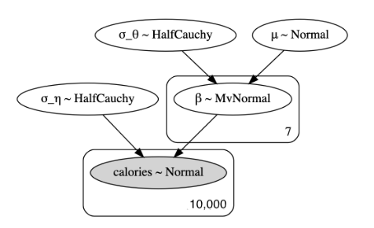

model2.2

##### 1. Specify the model

```r
mod_string = "model{
  for(i in 1:10000){
    y[i] ~ dnorm(mu[i], 1.0/25.0 )
    mu[i] = itc + b[1]*total_fat[i] + b[2]*sugar[i] + b[3]*sodium[i] +
      b[4]*protein[i] + b[5]*saturated_fat[i] + b[6]*carbohydrates[i]
  }
  # uninformative prior for intercept
  itc ~ dnorm(0.0, 1.0/25.0)
  # uninformative prior for coefficients
  b[1] ~ dnorm(9.0, 1.0/25.0)
  b[2] ~ dnorm(0.0, 1.0/25.0)
  b[3] ~ dnorm(0.0, 1.0/25.0)
  b[4] ~ dnorm(4.0, 1.0/25.0)
  b[5] ~ dnorm(9.0, 1.0/25.0)
  b[6] ~ dnorm(4.0, 1.0/25.0)
}"
```

##### 2. Set up the Model

```r
# monitor target posterior parameters
params = c('b', 'itc')
# training data for the model
data_jags = list(y = Y.train,
                 total_fat = X.train[,'total_fat'],
                 sugar = X.train[,'sugar'],
                 sodium = X.train[,'sodium'],
                 protein = X.train[,'protein'],
                 saturated_fat = X.train[,'saturated_fat'],
                 carbohydrates = X.train[,'carbohydrates'])
# generate jags model object
mod2.2 = jags.model(textConnection(mod_string), data = data_jags, n.chains = 3)
# burn-in
update(mod2.2, 1e3)
```

##### 3. Fit model - run MCMC sampler

```r
# 3. Fit model - run MCMC sampler
mod2.2_sim = coda.samples(mod2.2, variable.names = params, n.iter = 5e3)
mod2.2_csim = as.mcmc(do.call(rbind, mod2.2_sim))
```

##### 4. Convergence Diagnose

```r
# traceplot
# plot(mod2.1_sim, ask = TRUE) # plot per parameter
# gelman diagnose
gelman.diag(mod2.2_sim)
```

```
## Potential scale reduction factors:
##
##      Point est. Upper C.I.
## b[1]          1          1
## b[2]          1          1
## b[3]          1          1
## b[4]          1          1
## b[5]          1          1
## b[6]          1          1
## itc           1          1
##
## Multivariate psrf
##
## 1
```

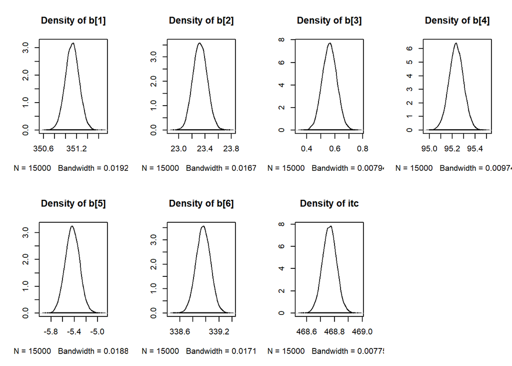

```r
# Model evaluation - DIC
dic2.2 = dic.samples(mod2.2, n.iter = 1e3)
# posterior distribution density plots
par(mfrow = c(2,4))
densplot(mod2.2_csim[,1:7])
```

##### 5. conclusion

From the density plots, the posterior distributions of coefficients we want to estimate converge well using MCMC sampling method, and give us point estimates for coefficients.

#### Hierarchical Linear Regression with uninformative prior

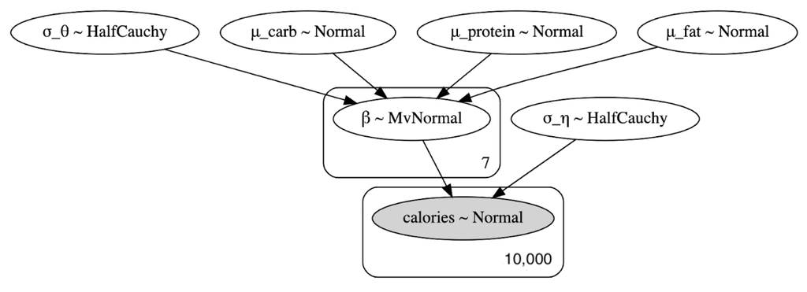

model2.3

##### 1. Specify the model

```r
mod_string = "model{
  for(i in 1:10000){
    y[i] ~ dnorm(mean[i], prec_error)
    mean[i] = itc + b[1]*total_fat[i] + b[2]*sugar[i] + b[3]*sodium[i] + b[4]*protein[i] + b[5]*saturated_fat[i] + b[6]*carbohydrates[i]
  }
  # uninformative prior for intercept
  itc ~ dnorm(mu, prec)
  # uninformative prior for coefficients
  for(j in 1:6){
    b[j] ~ dnorm(mu, prec)
  }

  # prior for prior
  mu ~ dnorm(0.0, 1.0/25.0)
  prec ~ dgamma(1/2.0, 1*10.0/2.0)
  prec_error ~ dgamma(1/2.0, 5*10.0/2.0)
}"
```

##### 2. Set up the Model

```r
# monitor target posterior parameters
params = c('b', 'itc')
# training data for the model
data_jags = list(y = Y.train,
                 total_fat = X.train[,'total_fat'],
                 sugar = X.train[,'sugar'],
                 sodium = X.train[,'sodium'],
                 protein = X.train[,'protein'],
                 saturated_fat = X.train[,'saturated_fat'],
                 carbohydrates = X.train[,'carbohydrates'])
# generate jags model object
mod2.3 = jags.model(textConnection(mod_string), data = data_jags, n.chains = 3)
# burn-in
update(mod2.3, 1e3)
```

##### 3. Fit model - run MCMC sampler

```r
mod2.3_sim = coda.samples(mod2.3, variable.names = params, n.iter = 5e3)
mod2.3_csim = as.mcmc(do.call(rbind, mod2.3_sim))
```

##### 4. Convergence Diagnose

```r
# traceplot
# plot(mod2.3_sim, ask = TRUE) # plot per parameter
# gelman diagnose
gelman.diag(mod2.3_sim)
```

```
## Potential scale reduction factors:
##
##      Point est. Upper C.I.
## b[1]          1       1.00
## b[2]          1       1.01
## b[3]          1       1.00
## b[4]          1       1.00
## b[5]          1       1.00
## b[6]          1       1.00
## itc           1       1.00
##
## Multivariate psrf
##
## 1
```

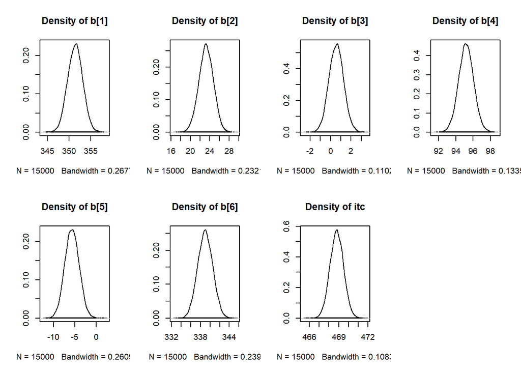

```r
# Model evaluation - DIC
dic2.3 = dic.samples(mod2.3, n.iter = 1e3)
# posterior distribution density plots
par(mfrow = c(2,4))
densplot(mod2.3_csim[,1:7])
```

##### 5. conclusion

From the density plots, the posterior distributions of coefficients we want to estimate converge well using MCMC sampling method, and give us point estimates for coefficients.

#### Hierarchical Linear Regression with subjective prior

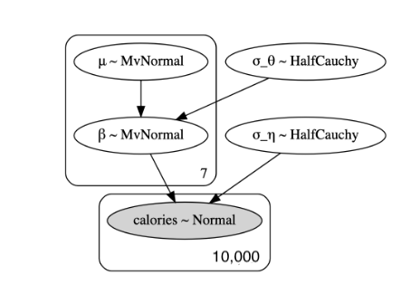

model2.4

##### 1. Specify the model

```r
mod_string = "model{
  for(i in 1:10000){
    y[i] ~ dnorm(mu[i], prec_error)
    mu[i] = itc + b[1]*total_fat[i] + b[2]*sugar[i] + b[3]*sodium[i] +
      b[4]*protein[i] + b[5]*saturated_fat[i] + b[6]*carbohydrates[i]
  }
  # prior for intercept
  itc ~ dnorm(mu_itc, prec)
  # prior for coefficients
  b[1] ~ dnorm(mu1, prec)
  b[2] ~ dnorm(mu2, prec)
  b[3] ~ dnorm(mu3, prec)
  b[4] ~ dnorm(mu4, prec)
  b[5] ~ dnorm(mu5, prec)
  b[6] ~ dnorm(mu6, prec)

  # prior for prior
  mu_itc ~ dnorm(0.0, 1.0/25.0)
  mu1 ~ dnorm(9.0, 1.0/25.0)
  mu2 ~ dnorm(0.0, 1.0/25.0)
  mu3 ~ dnorm(0.0, 1.0/25.0)
  mu4 ~ dnorm(4.0, 1.0/25.0)
  mu5 ~ dnorm(9.0, 1.0/25.0)
  mu6 ~ dnorm(4.0, 1.0/25.0)
  prec ~ dgamma(1/2.0, 1*10.0/2.0)
  prec_error ~ dgamma(1/2.0, 5*10.0/2.0)
}"
```

##### 2. Set up the Model

```r
# monitor target posterior parameters
params = c('b', 'itc')
# training data for the model
data_jags = list(y = Y.train,
                 total_fat = X.train[,'total_fat'],
                 sugar = X.train[,'sugar'],
                 sodium = X.train[,'sodium'],
                 protein = X.train[,'protein'],
                 saturated_fat = X.train[,'saturated_fat'],
                 carbohydrates = X.train[,'carbohydrates'])
# generate jags model object
mod2.4 = jags.model(textConnection(mod_string), data = data_jags, n.chains = 3)
# burn-in
update(mod2.4, 1e3)
```

##### 3. Fit model - run MCMC sampler

```r
mod2.4_sim = coda.samples(mod2.4, variable.names = params, n.iter = 5e3)
mod2.4_csim = as.mcmc(do.call(rbind, mod2.4_sim))
```

##### 4. Convergence Diagnose

```r
# traceplot
# plot(mod2.1_sim, ask = TRUE) # plot per parameter
# gelman diagnose
gelman.diag(mod2.4_sim)
```

```
## Potential scale reduction factors:
##
##      Point est. Upper C.I.
## b[1]          1          1
## b[2]          1          1
## b[3]          1          1
## b[4]          1          1
## b[5]          1          1
## b[6]          1          1
## itc           1          1
##
## Multivariate psrf
##
## 1
```

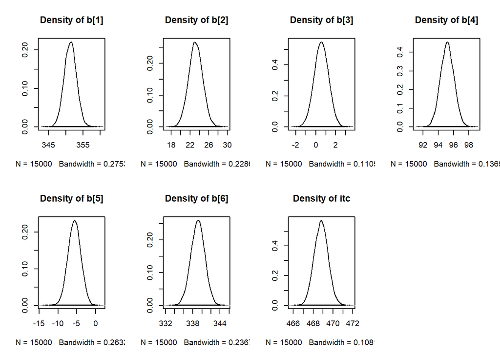

```r
# Model evaluation - DIC
dic2.4 = dic.samples(mod2.4, n.iter = 1e3)
# posterior distribution density plots
par(mfrow = c(2,4))
densplot(mod2.4_csim[,1:7])
```

##### 5. conclusion

From the density plots, the posterior distributions of coefficients we want to estimate converge well using MCMC sampling method, and give us point estimates for coefficients.